```r
# ---- Cleanup everything before start ----
options(warn=-1)
options(repos="https://cran.rstudio.com" )
rm(list = ls())
gc()
```

```
##          used (Mb) gc trigger (Mb) max used (Mb)
## Ncells 480093 25.7     940480 50.3   750400 40.1
## Vcells 897700  6.9    1650153 12.6  1034764  7.9
```

```r
list.of.packages <- c("FSelector", "ggplot2")
new.packages <- list.of.packages[!(list.of.packages %in% installed.packages()[,"Package"])]
if(length(new.packages)) install.packages(new.packages, repos="http://cran.rstudio.com/")
library(FSelector)
library(ggplot2)
library(RWeka)
install.packages("repr")
library(repr)

#---- GBSERVER API ----
source("./Rscript/experimentAPI.R")
# ---- INPUT and CONFIGURATIONS ----

EDGE_TYPE_FILE = "./data/infobox.edgetypes"
CLUSTER_SIZE = 2 # Number of workers in gbserver
FALSE_PER_TRUE = 5
DISCARD_REL = 191
ASSOCIATE_REL = c(404)
max_depth = 3

# ---- Load edge type file ----
mapfile <- read.csv(EDGE_TYPE_FILE, sep="\t", header=F)
mapfile$V1 <- as.numeric(mapfile$V1)
mapfile$V2 <- as.character(mapfile$V2)
```

## Test case 1: 50 true US capital-state and 250 US false capital-state

```r
# ---- Load input data ----
INPUT_FILE = "./data_id/state_capital.csv"
dat_state_capital.true <- read.csv(INPUT_FILE)
if (ncol(dat_state_capital.true) < 3)
  dat_state_capital.true$label <- T

# ---- Construct false labeled data -----
set.seed(233)
dat_state_capital.false <- rbind.fill(apply(dat_state_capital.true, 1, function(x){
  candidates <- unique(dat_state_capital.true[which(dat_state_capital.true[,1] != x[1]), 2])
  candidates <- unlist(lapply(candidates, function(y){
    if(length(which(dat_state_capital.true[,1] == x[1] & dat_state_capital.true[,2] == y) != 0)) {
      return(NULL)
    }
    return(y)
  }))
  return(data.frame(src=x[1],
                    dst=sample(candidates, FALSE_PER_TRUE),
                    label=F))
}))
colnames(dat_state_capital.true) <- c("src","dst","label")
dat_state_capital <- rbind(dat_state_capital.true, dat_state_capital.false)
```

# Test 1: Discriminative predicate paths

```r
tmp.paths <- read.csv("./Predicate_paths/capitals_1.csv", header = T)
tmp.paths$X <- NULL
dkm <- read.csv("./Predicate_paths/capitals_1.csv", header = F)
dkm$V1 <- NULL
colnames(tmp.paths) <- as.character(unlist(dkm[1,]))
```

# Test 1: 10 fold cross validation ( using all possible predicate paths)

```r
res_capital_state<- list()
res_capital_state[["raw"]] <- tmp.paths
res_capital_state[["model"]] <- Logistic(label~.,res_capital_state[["raw"]])
res_capital_state[["eval"]] <- evaluate_Weka_classifier(res_capital_state[["model"]], numFolds = 10, complexity = T, class = T, seed = 233)
res_capital_state[["eval"]]
```

```
## === 10 Fold Cross Validation ===
##
## === Summary ===
##
## Correctly Classified Instances         299               99.6667 %
## Incorrectly Classified Instances         1                0.3333 %
## Kappa statistic                          0.9879
## K&B Relative Info Score              28968.5641 %
## K&B Information Score                  189.9418 bits      0.6331 bits/instance
## Class complexity | order 0             195.016  bits      0.6501 bits/instance
## Class complexity | scheme               21.7656 bits      0.0726 bits/instance
## Complexity improvement     (Sf)        173.2504 bits      0.5775 bits/instance
## Mean absolute error                      0.0081
## Root mean squared error                  0.0635
## Relative absolute error                  2.9071 %
## Root relative squared error             17.0297 %
## Total Number of Instances              300
##
## === Detailed Accuracy By Class ===
##
##                  TP Rate  FP Rate  Precision  Recall   F-Measure  MCC      ROC Area  PRC Area  Class
##                  1.000    0.020    0.996      1.000    0.998      0.988    0.999     1.000     FALSE
##                  0.980    0.000    1.000      0.980    0.990      0.988    0.999     0.997     TRUE
## Weighted Avg.    0.997    0.017    0.997      0.997    0.997      0.988    0.999     0.999
##
## === Confusion Matrix ===
##
##    a   b   <-- classified as
##  250   0 |   a = FALSE
##    1  49 |   b = TRUE
```

# Test 1: Feature selection validation (weighing predicate paths basing on their correlation with labels)

```r
# ---- Feature selection validation ----
weights_capital_state <- information.gain(label~., res_capital_state[["raw"]])
weights_capital_state <- weights_capital_state[order(weights_capital_state[,1], decreasing = T),,drop=F]

# ---- Top related relations ----
features_captial_state <- data.frame(importance=weights_capital_state$attr_importance, path=row.names(weights_capital_state))

features_captial_state <- features_captial_state[order(-features_captial_state$importance),]

features_captial_state$path <- idpath2title(features_captial_state$path, mapfile)
weights_capital_state
```

```
##            attr_importance
## -38,38,         0.39627296
## -46,46,         0.39627296
## -40,39,         0.38198622
## -17,17,         0.38198622
## -16,16,         0.35572908
## -44,            0.35572908
## -39,39,         0.34347470
## -40,606,        0.29856871
## -85,85,         0.29373413
## -40,404,        0.28815404
## -40,-44,        0.27800474
## -15,16,         0.26809944
## -15,17,         0.26809944
## -103,103,       0.25841980
## -38,46,         0.25231214
## -39,240,        0.23967609
## -65,46,         0.22402173
## -65,38,         0.22110704
## -38,103,        0.21494066
## -115,16,        0.19586121
## -157,157,       0.19586121
## -65,103,        0.19586121
## -226,226,       0.18754720
## -46,38,         0.18032791
## -17,148,        0.17346069
## -46,167,        0.15750105
## -167,167,       0.14785550
## -29,253,        0.14025695
## -167,46,        0.14025695
## -16,17,         0.14025695
## -46,103,        0.13381037
## -17,16,         0.13301667
## -103,46,        0.11973881
## -44,44,         0.11806449
## -38,85,         0.11121913
## -103,38,        0.11085623
## -40,65,         0.10373722
## -24,24,         0.09823911
## -157,17,        0.09670453
```

[output cut: 189 more lines]

```
## -364,103,       0.00000000
## -31,39,         0.00000000
## -563,72,        0.00000000
## -563,73,        0.00000000
## -157,209,       0.00000000
## -17,212,        0.00000000
## -200,16,        0.00000000
## -38,86,         0.00000000
## -38,87,         0.00000000
## -85,86,         0.00000000
## -85,87,         0.00000000
## -69,39,         0.00000000
## -46,451,        0.00000000
## -103,184,       0.00000000
## -104,46,        0.00000000
```

```r
head(weights_capital_state)
```

```
##         attr_importance
## -38,38,       0.3962730
## -46,46,       0.3962730
## -40,39,       0.3819862
## -17,17,       0.3819862
## -16,16,       0.3557291
## -44,          0.3557291
```

```r
features_captial_state
```

```
##     importance
## 1   0.39627296
## 2   0.39627296
## 3   0.38198622
## 4   0.38198622
## 5   0.35572908
## 6   0.35572908
## 7   0.34347470
## 8   0.29856871
## 9   0.29373413
## 10  0.28815404
## 11  0.27800474
## 12  0.26809944
## 13  0.26809944
## 14  0.25841980
```

[output cut: 473 more lines]

```r
head(features_captial_state)
```

```
##   importance                        path
## 1  0.3962730   (-1)birthPlace,birthPlace
## 2  0.3962730   (-1)deathPlace,deathPlace
## 3  0.3819862              (-1)state,city
## 4  0.3819862       (-1)location,location
## 5  0.3557291 (-1)headquarter,headquarter
## 6  0.3557291                (-1)isPartOf
```

# Test 1:Cross validation of impact of top discriminative path of classification performance

# Calculate ROC area in term of number of retained top paths

```r
# ---- AOROC of predicated sub paths ----
fm_val <- function(resdf) {
  return(as.numeric(str_split(str_split(resdf$eval$string,"\n")[[1]][24], " +")[[1]][9]))
}
full_predicated_path <- res_capital_state[["raw"]]
cl <- makeCluster(2)
clusterExport(cl = cl, varlist=c("full_predicated_path", "weights_capital_state", "eval.df", "cutoff.k", "fm_val","str_split","as.numeric"), envir = environment())

res_AOROC <- rbind.fill(parLapply(cl, seq(1,ncol(full_predicated_path)-1,by = 5), function(x){
library(FSelector)
library(RWeka)
wekares<-eval.df(full_predicated_path[,c("label", cutoff.k(weights_capital_state, x))])
return(data.frame(AOROC=fm_val(wekares),nfeature=x))
}))
stopCluster(cl)
```

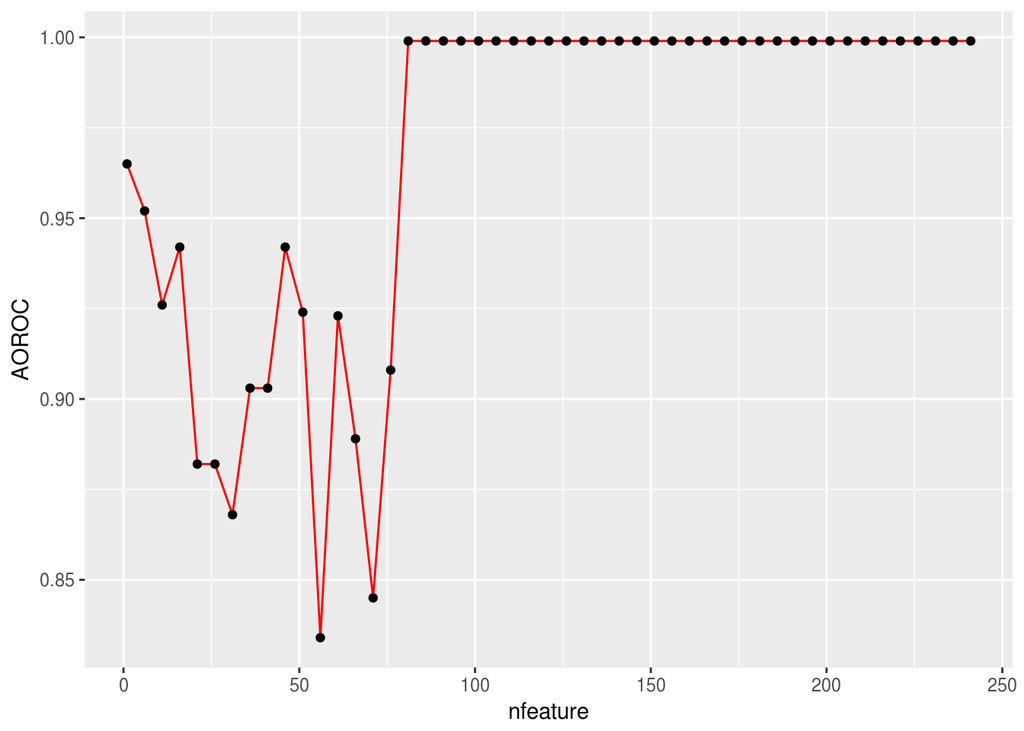

```r
ggplot(data=res_AOROC, aes(x=nfeature, y=AOROC, group=1)) +
  geom_line(color="red")+
  geom_point()
```

# Test 1: 10 fold cross validation ( only use top 10 predicate paths)

# Easily to classify False pair even using a few of discriminative paths, since in general, there is very few paths between 2 entities in false pairs.

# Misclassify some true pairs. Some of top 10 paths are trivial. May need another more efficient way to retrieve top paths

```r
full_predicated_path <- res_capital_state[["raw"]]
wekares<-eval.df(full_predicated_path[,c("label", cutoff.k(weights_capital_state, 10))])
res_capital_state[["raw"]]
```

[output not shown]

[output cut: 9918 more lines]

```r
features_captial_state[c(1:10),]
```

```
##    importance                        path
## 1   0.3962730   (-1)birthPlace,birthPlace
## 2   0.3962730   (-1)deathPlace,deathPlace
## 3   0.3819862              (-1)state,city
## 4   0.3819862       (-1)location,location
## 5   0.3557291 (-1)headquarter,headquarter
## 6   0.3557291                (-1)isPartOf
## 7   0.3434747               (-1)city,city
## 8   0.2985687        (-1)state,countySeat
## 9   0.2937341       (-1)hometown,hometown
## 10  0.2881540       (-1)state,largestCity
```

```r
wekares[["eval"]]
```

```
## === 10 Fold Cross Validation ===
##
## === Summary ===
##
## Correctly Classified Instances         295               98.3333 %
## Incorrectly Classified Instances         5                1.6667 %
## Kappa statistic                          0.9375
## K&B Relative Info Score              26966.3066 %
## K&B Information Score                  176.8133 bits      0.5894 bits/instance
## Class complexity | order 0             195.016  bits      0.6501 bits/instance
## Class complexity | scheme             1408.8381 bits      4.6961 bits/instance
## Complexity improvement     (Sf)      -1213.8221 bits     -4.0461 bits/instance
## Mean absolute error                      0.0243
## Root mean squared error                  0.1302
## Relative absolute error                  8.6918 %
## Root relative squared error             34.9263 %
## Total Number of Instances              300
##
## === Detailed Accuracy By Class ===
##
##                  TP Rate  FP Rate  Precision  Recall   F-Measure  MCC      ROC Area  PRC Area  Class
##                  1.000    0.100    0.980      1.000    0.990      0.939    0.925     0.953     FALSE
##                  0.900    0.000    1.000      0.900    0.947      0.939    0.925     0.933     TRUE
## Weighted Avg.    0.983    0.083    0.984      0.983    0.983      0.939    0.925     0.950
##
## === Confusion Matrix ===
##
##    a   b   <-- classified as
##  250   0 |   a = FALSE
##    5  45 |   b = TRUE
```

## Test case 2: 50 true US capital-state and 216 US largestcity-state pairs considered as false capital-state

# Test 2: Discriminative predicate paths for test 2

```r
tmp.paths <- read.csv("./Predicate_paths/capitals_3.csv")
tmp.paths$X <- NULL
dkm <- read.csv("./Predicate_paths/capitals_3.csv", header = F)
dkm$V1 <- NULL
colnames(tmp.paths) <- as.character(unlist(dkm[1,]))
```

# Test 2: 10 fold cross validation ( using all possible predicate paths)

# Misclassify both some true & false pairs. Since capital-state and largest-city share many same paths (ex. location, birthplace..) -> take into account all possible paths may lead to misclassification.

```r
res_capital_state_largestcity <- list()
res_capital_state_largestcity[["raw"]] <- tmp.paths
res_capital_state_largestcity[["model"]] <- Logistic(label~.,res_capital_state_largestcity[["raw"]])
res_capital_state_largestcity[["eval"]] <- evaluate_Weka_classifier(res_capital_state_largestcity[["model"]], numFolds = 10, complexity = T, class = T, seed = 233)
res_capital_state_largestcity[["eval"]]
```

```
## === 10 Fold Cross Validation ===
##
## === Summary ===
##
## Correctly Classified Instances         221               83.0827 %
## Incorrectly Classified Instances        45               16.9173 %
## Kappa statistic                          0.489
## K&B Relative Info Score               8524.6376 %
## K&B Information Score                   59.8126 bits      0.2249 bits/instance
## Class complexity | order 0             185.4685 bits      0.6973 bits/instance
## Class complexity | scheme             4569.3823 bits     17.1781 bits/instance
## Complexity improvement     (Sf)      -4383.9138 bits    -16.4809 bits/instance
## Mean absolute error                      0.1769
## Root mean squared error                  0.4129
## Relative absolute error                 57.636  %
## Root relative squared error            105.6698 %
## Total Number of Instances              266
##
## === Detailed Accuracy By Class ===
##
##                  TP Rate  FP Rate  Precision  Recall   F-Measure  MCC      ROC Area  PRC Area  Class
##                  0.870    0.340    0.917      0.870    0.893      0.493    0.814     0.929     FALSE
##                  0.660    0.130    0.541      0.660    0.595      0.493    0.790     0.518     TRUE
## Weighted Avg.    0.831    0.300    0.846      0.831    0.837      0.493    0.809     0.852
##
## === Confusion Matrix ===
##
##    a   b   <-- classified as
##  188  28 |   a = FALSE
##   17  33 |   b = TRUE
```

# Test 2: Feature selection validation (weighing predicate paths basing on their correlation with labels)

```r
# ---- Feature selection validation ----
weights_capital_state_largestcity <- information.gain(label~., res_capital_state_largestcity[["raw"]])
weights_capital_state_largestcity <- weights_capital_state_largestcity[order(weights_capital_state_largestcity[,1], decreasing = T),,drop=F]

# ---- Top related relations ----
features_captial_state_largestcity <- data.frame(importance=weights_capital_state_largestcity$attr_importance, path=row.names(weights_capital_state_largestcity))

features_captial_state_largestcity <- features_captial_state_largestcity[order(-features_captial_state_largestcity$importance),]

features_captial_state_largestcity$path <- idpath2title(features_captial_state_largestcity$path, mapfile)
weights_capital_state_largestcity
```

```
##            attr_importance
## -15,16,         0.20844717
## -15,17,         0.20844717
## -115,16,        0.09865185
## -29,253,        0.07283433
## -16,17,         0.06102960
## -46,46,         0.06031670
## -17,16,         0.05546129
## -38,46,         0.05096609
## -65,46,         0.05054174
## -16,16,         0.04976147
## -17,17,         0.03669437
## -19,16,         0.03221374
## -19,17,         0.03221374
## -40,39,         0.00000000
## -38,38,         0.00000000
## -39,240,        0.00000000
## -38,103,        0.00000000
## -39,39,         0.00000000
## -46,38,         0.00000000
## -103,103,       0.00000000
## 671,-671,       0.00000000
## -85,85,         0.00000000
## -103,38,        0.00000000
## -294,294,       0.00000000
## -46,167,        0.00000000
## -115,157,       0.00000000
## -157,157,       0.00000000
## -167,46,        0.00000000
## -226,226,       0.00000000
## -253,253,       0.00000000
## -277,277,       0.00000000
## -277,38,        0.00000000
## 29,-29,         0.00000000
## -38,85,         0.00000000
## -40,404,        0.00000000
## -40,-44,        0.00000000
## -40,606,        0.00000000
## -40,72,         0.00000000
## -40,73,         0.00000000
```

[output cut: 411 more lines]

```
## -404,404,       0.00000000
## -173,46,        0.00000000
## -22,22,         0.00000000
## -523,38,        0.00000000
## -143,38,        0.00000000
## -292,46,        0.00000000
## -40,-431,       0.00000000
## -126,22,        0.00000000
## -143,21,        0.00000000
## -100,298,       0.00000000
## -298,13,        0.00000000
## -13,17,         0.00000000
## -13,37,         0.00000000
## -6,6,           0.00000000
## -134,38,        0.00000000
```

```r
head(weights_capital_state_largestcity)
```

```
##          attr_importance
## -15,16,       0.20844717
## -15,17,       0.20844717
## -115,16,      0.09865185
## -29,253,      0.07283433
## -16,17,       0.06102960
## -46,46,       0.06031670
```

```r
features_captial_state_largestcity
```

```
##     importance
## 1   0.20844717
## 2   0.20844717
## 3   0.09865185
## 4   0.07283433
## 5   0.06102960
## 6   0.06031670
## 7   0.05546129
## 8   0.05096609
## 9   0.05054174
## 10  0.04976147
## 11  0.03669437
## 12  0.03221374
## 13  0.03221374
## 14  0.00000000
```

[output cut: 917 more lines]

```r
head(features_captial_state_largestcity)
```

```
##   importance                         path
## 1 0.20844717 (-1)jurisdiction,headquarter
## 2 0.20844717    (-1)jurisdiction,location
## 3 0.09865185 (-1)regionServed,headquarter
## 4 0.07283433         (-1)country,garrison
## 5 0.06102960     (-1)headquarter,location
## 6 0.06031670    (-1)deathPlace,deathPlace
```

# Test 2: Cross validation of impact of top discriminative path of classification performance

# Calculate ROC area in term of number of retained top paths

```r
# ---- AOROC of predicated sub paths ----
fm_val <- function(resdf) {
  return(as.numeric(str_split(str_split(resdf$eval$string,"\n")[[1]][24], " +")[[1]][9]))
}
full_predicated_path <- res_capital_state_largestcity[["raw"]]
cl <- makeCluster(2)
clusterExport(cl = cl, varlist=c("full_predicated_path", "weights_capital_state_largestcity", "eval.df", "cutoff.k", "fm_val","str_split","as.numeric"), envir = environment())

res_AOROC_largestcity <- rbind.fill(parLapply(cl, seq(1,ncol(full_predicated_path)-1,by = 5), function(x){
library(FSelector)
library(RWeka)
wekares<-eval.df(full_predicated_path[,c("label", cutoff.k(weights_capital_state_largestcity, x))])
return(data.frame(AOROC=fm_val(wekares),nfeature=x))
}))
stopCluster(cl)
```

# Some first paths may have more useful information.

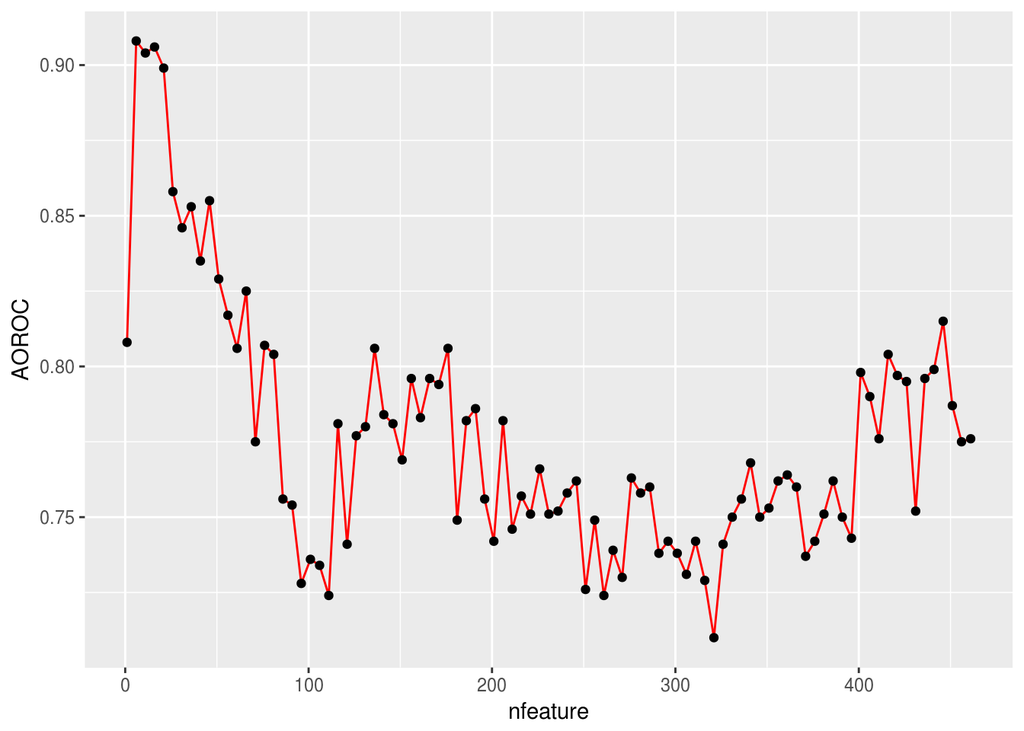

```r
ggplot(data=res_AOROC_largestcity, aes(x=nfeature, y=AOROC, group=1)) +
  geom_line(color="red")+
  geom_point()
```

# Test 2: 10 fold cross validation ( only use top 6 predicate paths)

# Clear improvement in classification of false pairs -> show that these paths are really discriminative.

# But using only these paths seems not enough for classification of true pairs. May need more paths.

```r
full_predicated_path <- res_capital_state_largestcity[["raw"]]
wekares<-eval.df(full_predicated_path[,c("label", cutoff.k(weights_capital_state_largestcity, 6))])
features_captial_state_largestcity[c(1:6),]
```

```
##   importance                         path
## 1 0.20844717 (-1)jurisdiction,headquarter
## 2 0.20844717    (-1)jurisdiction,location
## 3 0.09865185 (-1)regionServed,headquarter
## 4 0.07283433         (-1)country,garrison
## 5 0.06102960     (-1)headquarter,location
## 6 0.06031670    (-1)deathPlace,deathPlace
```

```r
wekares[["eval"]]
```

```
## === 10 Fold Cross Validation ===
##
## === Summary ===
##
## Correctly Classified Instances         242               90.9774 %
## Incorrectly Classified Instances        24                9.0226 %
## Kappa statistic                          0.6798
## K&B Relative Info Score              14862.5576 %
## K&B Information Score                  104.2823 bits      0.392  bits/instance
## Class complexity | order 0             185.4685 bits      0.6973 bits/instance
## Class complexity | scheme              104.2972 bits      0.3921 bits/instance
## Complexity improvement     (Sf)         81.1713 bits      0.3052 bits/instance
## Mean absolute error                      0.1262
## Root mean squared error                  0.258
## Relative absolute error                 41.1182 %
## Root relative squared error             66.0336 %
## Total Number of Instances              266
##
## === Detailed Accuracy By Class ===
##
##                  TP Rate  FP Rate  Precision  Recall   F-Measure  MCC      ROC Area  PRC Area  Class
##                  0.968    0.340    0.925      0.968    0.946      0.686    0.908     0.962     FALSE
##                  0.660    0.032    0.825      0.660    0.733      0.686    0.908     0.807     TRUE
## Weighted Avg.    0.910    0.282    0.906      0.910    0.906      0.686    0.908     0.933
##
## === Confusion Matrix ===
##
##    a   b   <-- classified as
##  209   7 |   a = FALSE
##   17  33 |   b = TRUE
```